# Statistical Analysis in R

## Setup

```r
## remove all user defined objects in your workspace
rm(list=ls())

library(tidyverse)  # Provides functions used throughout this session

biochem <- read_csv("biochem_wide.csv")
```

## Summarize

### What is the distribution of Alkaline Phosphatase results?

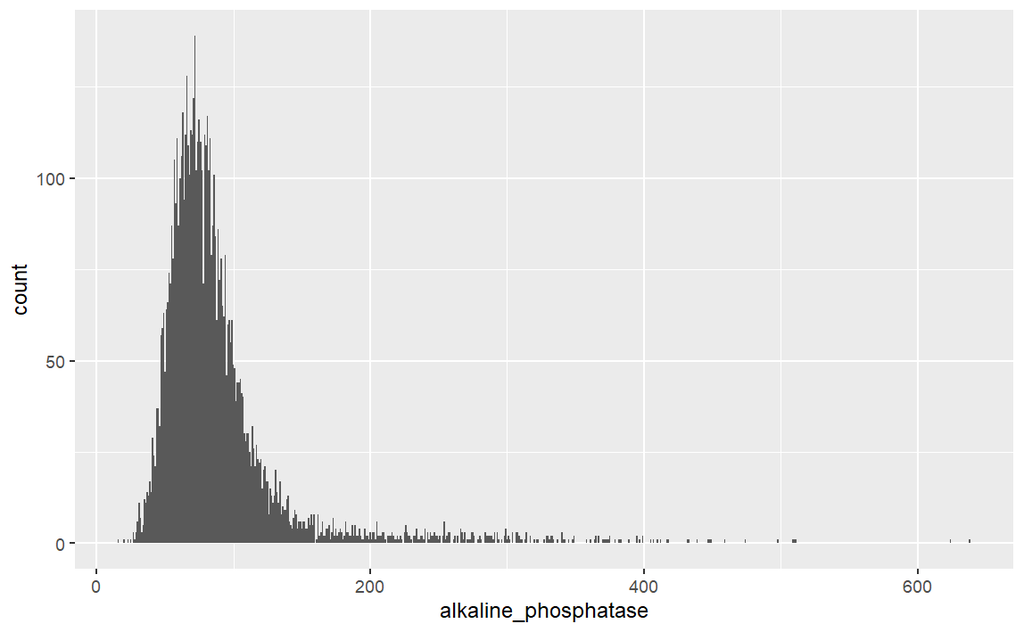

```r
ggplot(data = biochem) +
  geom_histogram(aes(x = alkaline_phosphatase), binwidth = 1)
```

### Summarize the total number of of alkaline phosphatase results.

```r
biochem %>%
  select(mrn, alkaline_phosphatase) %>%
    summarize(test_count = n())
```

| test_count |
| --- |
| 6481 |

```r
NA
```

## Your Turn 1

Fill in gaps in code below to:

1. Calculate the median alkaline phosphatase (“alkaline_phosphatase”) concentration and average calcium (“total_calcium”) concentration.

```r
stats_1a <- biochem %>%
    summarize(test_count = n(),
              mean_alp = median(alkaline_phosphatase),
              mean_ca = mean(total_calcium))
stats_1a
```

| test_count | mean_alp | mean_ca |
| --- | --- | --- |
| 6481 | 77 | 9.302206 |

2. Calculate the interquartile range for alkaline phosphatase and the standard deviation for calcium. The function for interquartile range is “IQR” and for standard deviation is “sd”

```r
stats_1b <- biochem %>%
    summarize(test_count = n(),
              median_alp = median(alkaline_phosphatase),
              mean_ca = mean(total_calcium),
              iqr_alp = IQR(alkaline_phosphatase),
              sd_ca = sd(total_calcium))
stats_1b
```

| test_count | median_alp | mean_ca | iqr_alp | sd_ca |
| --- | --- | --- | --- | --- |
| 6481 | 77 | 9.302206 | 34 | 0.3808856 |

## Other examples of summarize

```r
stats_1c <- biochem %>%
  summarize(test_count = n(),
              lower95_alp = quantile(alkaline_phosphatase, 0.025),
            upper95_alp = quantile(alkaline_phosphatase, 0.975),
              var_alp = var(alkaline_phosphatase),
              cv_alp = 100*sd(alkaline_phosphatase)/mean(alkaline_phosphatase))

stats_1c
```

| test_count | lower95_alp | upper95_alp | var_alp | cv_alp |
| --- | --- | --- | --- | --- |
| 6481 | 42 | 254 | 2625.381 | 57.29755 |

Consider: How would you calculate the total number of tests performed by patient gender?

## group_by

```r
biochem %>%
  select(mrn, gender, pat_type) %>%
  group_by(gender, pat_type)
```

[output not shown]

## group_by %>% summarize

```r
gend_cnt <- biochem %>%
    select(mrn, gender, alkaline_phosphatase) %>%
  group_by(gender) %>%
  summarize(test_count = n())
gend_cnt
```

[output not shown]

## Your Turn 2

1. Calculate the median alkaline phosphatase concentration for Men and Women

```r
biochem %>%
  ________(______) %>%
  summarize(median_alp = median(alkaline_phosphatase))
```

2. Calculate the median alkaline phosphatase concentration in Men and Women over 51

```r
biochem %>%
  ________(______) %>%
  ______(___ > __) %>%
  summarize(median_alp = _(alkaline_phosphatase)_
```

## Joining Multiple Dataframes Together

I want to add the total number of Males and Females to each row of the biochemistry dataset.

```r
left_example <- left_join(biochem, gend_cnt, by="gender")
left_example

right_example <- right_join(biochem, gend_cnt, by="gender")
right_example

inner_example <- inner_join(biochem, gend_cnt, by="gender")
inner_example

full_example <- full_join(biochem, gend_cnt, by="gender")
full_example
```

[output not shown]

## Your turn

Use the approriate join command to combine the stats_1b dataframe and stats_1c dataframe using the test_count column.

```r
all_stats <- _________(stats_1b, stats_1c, __ = "________")
all_stats
```

## What else

```r
#filter males over 51
biochem_male <- biochem %>%
  filter(gender == "Male" & age >51)

#filter females over 51
biochem_female <- biochem %>%
  filter(gender == "Female" & age > 51)

#create variables for alkaline phosphatase
alp_male <- biochem_male$alkaline_phosphatase
alp_female <- biochem_female$alkaline_phosphatase

#perform unpaired wilkoxon rank sum test
wilcox.test(alp_male, alp_female, paired=FALSE)
```

```
    Wilcoxon rank sum test with continuity correction

data:  alp_male and alp_female
W = 767533, p-value < 2.2e-16
alternative hypothesis: true location shift is not equal to 0
```

### Linear Regression

```r
#creates linear regression model
lm.model <- lm(blood_urea_nitrogen ~ creatinine + aspartate_aminotransferase, biochem)
summary(lm.model)
```

```
Call:
lm(formula = blood_urea_nitrogen ~ creatinine + aspartate_aminotransferase,
    data = biochem)

Residuals:
    Min      1Q  Median      3Q     Max
-39.371  -3.174  -0.717   2.312  54.763

Coefficients:
                             Estimate Std. Error t value Pr(>|t|)
(Intercept)                 9.1789031  0.1571702  58.401   <2e-16 ***
creatinine                  6.0252614  0.1179074  51.102   <2e-16 ***
aspartate_aminotransferase -0.0004265  0.0047002  -0.091    0.928
---
Signif. codes:  0 ‘***’ 0.001 ‘**’ 0.01 ‘*’ 0.05 ‘.’ 0.1 ‘ ’ 1

Residual standard error: 5.038 on 6478 degrees of freedom
Multiple R-squared:  0.2873,    Adjusted R-squared:  0.2871
F-statistic:  1306 on 2 and 6478 DF,  p-value: < 2.2e-16
```

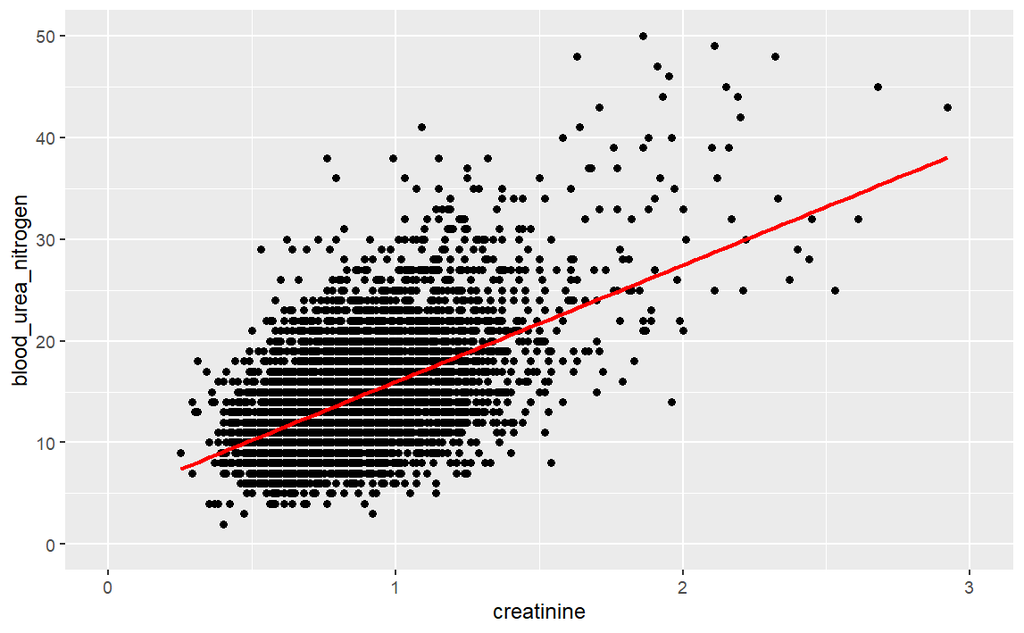

```r
#scatterplot of creatinine vs. BUN
ggplot(biochem, aes(creatinine, blood_urea_nitrogen)) +
  geom_point() +
  xlim(0,3) +
  ylim(0,50)+
  geom_smooth(method="lm", se=FALSE, color="red", formula = y ~ x)
```

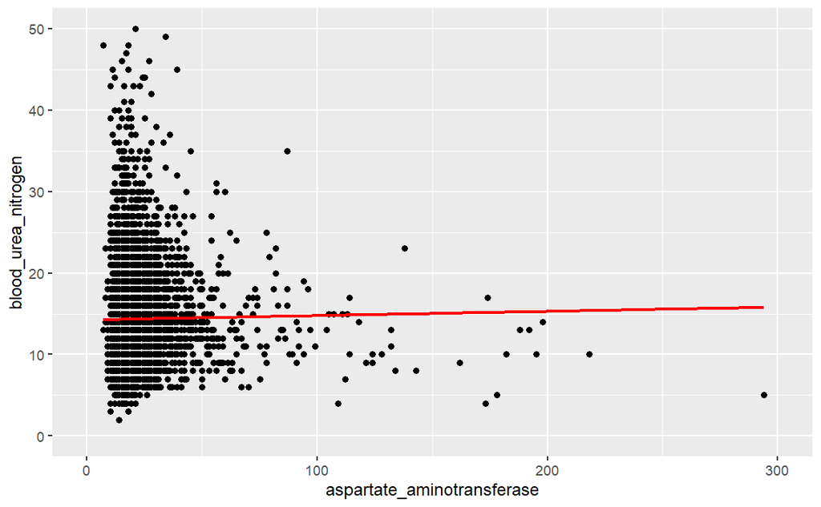

```r
#scatterplot of AST vs. BUN
ggplot(biochem, aes(aspartate_aminotransferase, blood_urea_nitrogen)) +
  geom_point() +
  xlim(0,300) +
  ylim(0,50)+
  geom_smooth(method="lm", se=FALSE, color="red", formula = y ~ x)
```

```r
#report model coefficients
lm.model$coefficients
```

```
               (Intercept)                 creatinine aspartate_aminotransferase
              9.1789030681               6.0252613643              -0.0004265224
```

```r
#report confidence of model coefficients
confint(lm.model)
```

```
                                  2.5 %      97.5 %
(Intercept)                 8.870797536 9.487008600
creatinine                  5.794123926 6.256398803
aspartate_aminotransferase -0.009640378 0.008787334
```

## Your turn!

Perform a linear regression of Alkaline Phosphatase as a function of gender and age. What happens when you perform a linear regerssion with a categorical variable?

For this one you’re all on your own!

```r
## create linear regression model

##summarize the model

## extract model coefficient

## extract confidence intervals
```